# **Common Factors Affecting Loans at various states in the US**

## **Data Investigation**

#### I want to look into the factors or features that had an effect on amount loaned out, as well as the various people who were most likely to default a loan payment

## **Dataset Overview**

#### This ProsperLoan data set contains 113,937 loans with 81 variables on each loan

#### For simplicity of the visualization I have looked at only few variables. The main dataframe was broken down into various datasets through the projects for simplicity and for easy analysis

### **What is/are the main feature(s) of interest in your dataset?**

I'm interested in knowing what type of people default loans, and the correlation among some series.

### **What percentage of Applicants defaulted payment?**

```
0    98.838826
1     1.161174
Name: did_they_default, dtype: float64
```

### **Distribution of borrowers credit ratings**

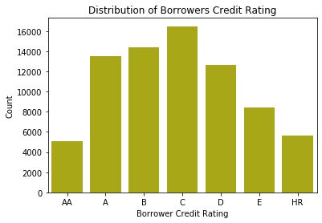

### **Which state defaulted the most with the Loans?**

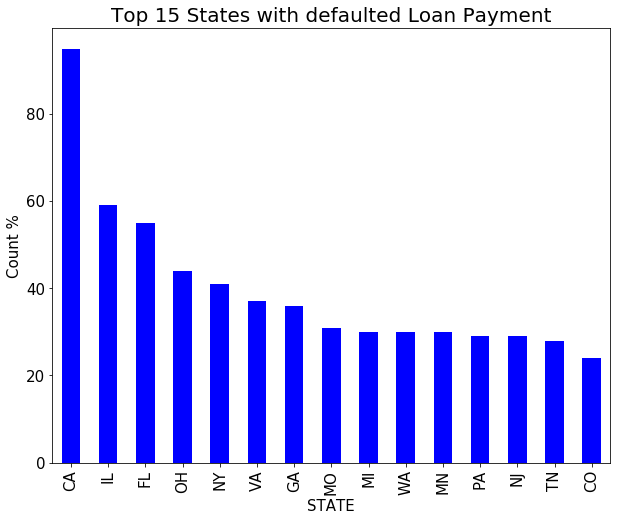

### **What was the majority of the loans used for?**

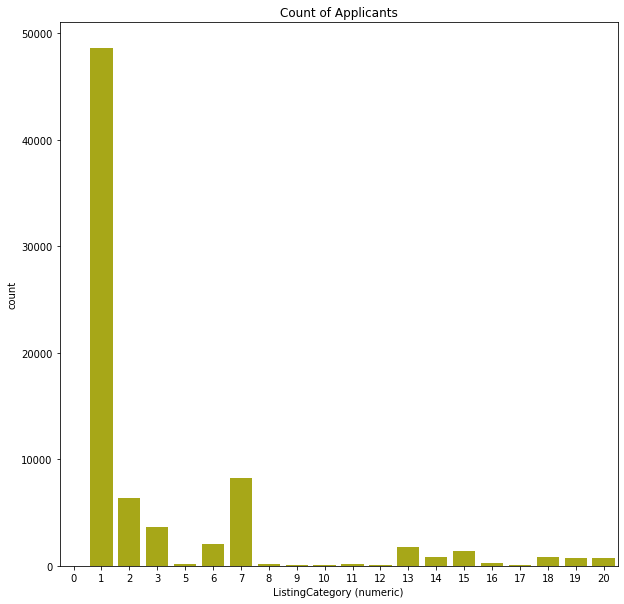

### **What values have an effect on the amount loaned? How does the various numeric value correlate with one another.**

##### The variables are : 'StatedMonthlyIncome', 'Recommendations', 'EmploymentStatusDuration', 'BorrowerRate', 'EstimatedReturn', 'DebtToIncomeRatio'

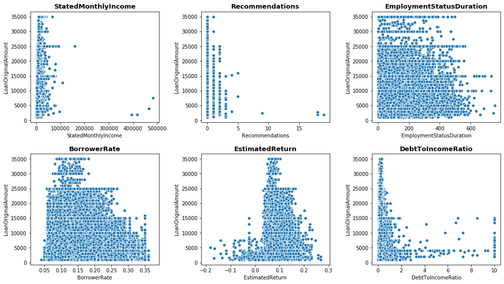

### **Variation of amount loaned out across various Income ranges.**

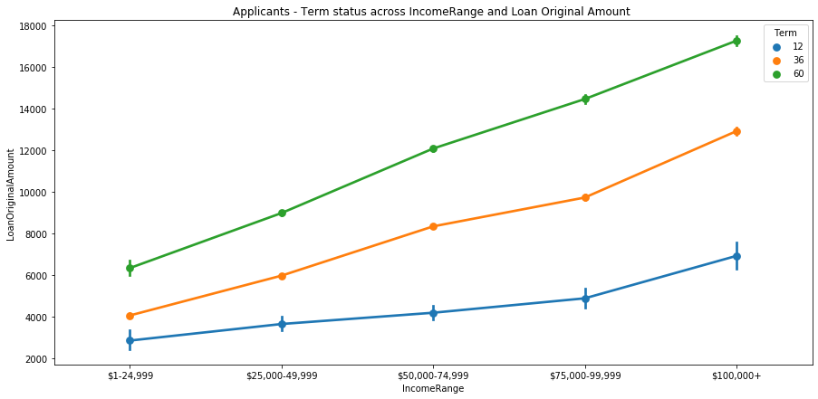

## **Summary and Observations**

All null values were removed for easy analysis

Not all applicants are emloyed

For defaulters, majority of the loan types given to them fall under the category of poorly rated loans, with only very few of them given highly rated loans.

Majority of the loan applicants income range are from 100k and greater with emloyed status

The distribution of amount loaned of applicants is right skewed because there are few applicants with high loan demand.

LoanStatus with "current" and "completed" have their own homes as at when they applied for loans

"Professional" as an occupation had the highest number of defaulters.

Based on the ratio of deafuters to the ratio of loan recepients RD and SI states are the most likely to default payment

The major reason for loan collection by most of the applicants was for "Debt Consolidation" by a great amount, this might want to be looked at.